# bio720 assignment 11.18

Jerry

2018年11月18日

# Data Visualization with ggplot2: Introduction

## Exploratory vs Explanatory

- Exploratory visualizations: Graphical data analysis. Easily generated, data-heavy, intended for a small specialist audience.
- Explanatory visualizations: Communication process. Labor-intensive, data-specific, intended for a broader audience.

## Exploring ggplot2 part1

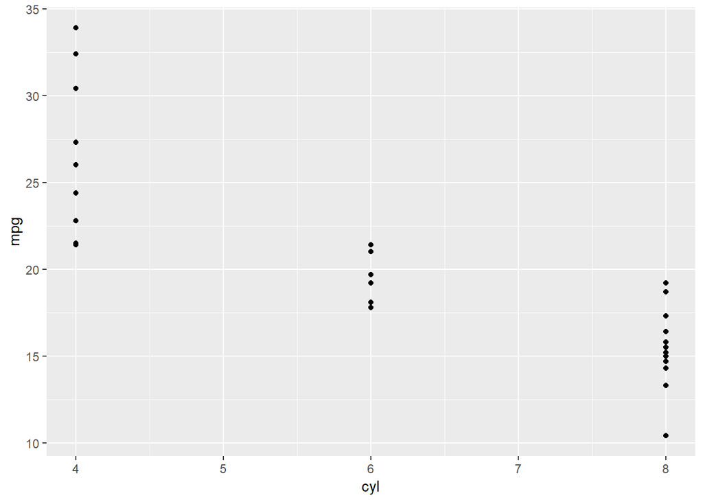

```r
library(ggplot2)
ggplot(mtcars, aes(x = cyl, y = mpg)) +
  geom_point()
```

-Load the ggplot2 package first.

-Deifine x axis and y axis: x = *, y =* )

-geom_point(): Scatter plot

-Notice that ggplot2 treats cyl as a continuous variable, which is wrong.

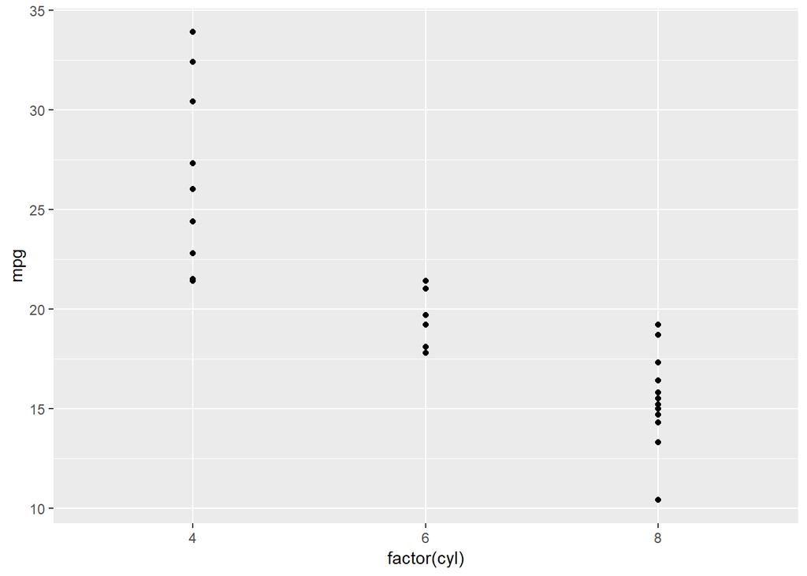

```r
ggplot(mtcars, aes(x = factor(cyl), y = mpg)) +
  geom_point()
```

- Wrapping factor() around cyl: ggplot2 treats cyl as a factor. Problem is fixed.

## Exploring ggplot2 part2

### Other aesthetics

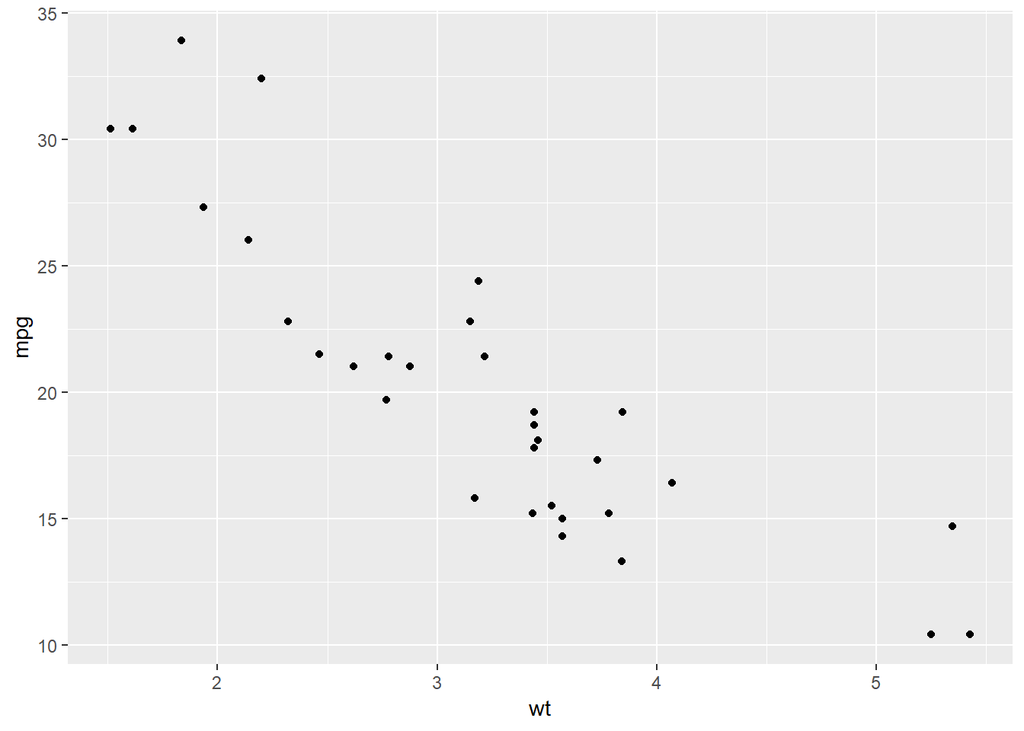

```r
ggplot(mtcars, aes(x = wt, y = mpg)) +
  geom_point()
```

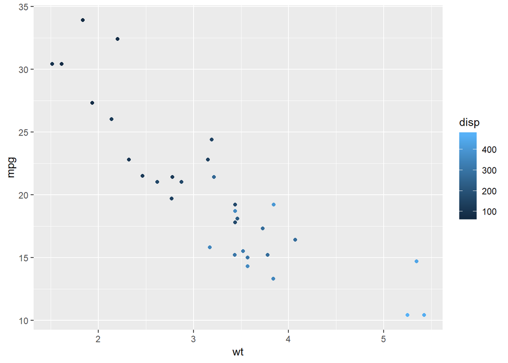

```r
ggplot(mtcars, aes(x = wt, y = mpg, color = disp)) +
  geom_point()
```

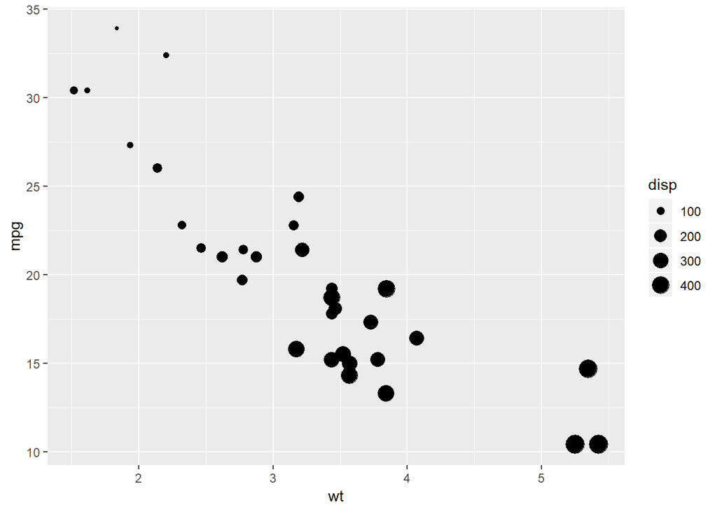

```r
ggplot(mtcars, aes(x = wt, y = mpg, size = disp)) +
  geom_point()
```

-color =/size = : Legend for the color and size scales was generated(dependent on disp).

### Understanding Variables

ggplot(mtcars, aes(x = wt, y = mpg, shape = disp)) + geom_point()

-This(shape = disp) gives you an error: only makes sense with categorical data, and disp is continuous.